# Introduction to GIS and mapping in R

Cascadia R Conference 2026

Brittany Barker

2026-06-26

## Your instructors: Brittany Barker

[figure not shown]

**Current position**  
- Asst. Research Professor, OSU  
**Research interests**  
- Modeling, ecology, biogeography, conservation  
**Hobbies**  
- Running, hiking, biking, moving!  
- Gardening, native habitat restoration  
- Artistic and creative endeavors  
**R Community**  
- Co-organize “Aggregate” meetups  
- Co-organize Cascadia R Conference

## Outline of workshop

- ~25 min: introductory lecture
- Parts 1-2: Introduction to sf package
- Part 3: Mapping raster and vector data (ggplot2)
- Part 4: Mapping raster and vector date (leaflet)

[figure not shown]

Source: Zia Ahmed

## Elements of Geographic Information System (GIS)

[figure not shown]

Source: Mierzejowska & Pomyko 2019

## Why use R for GIS?

- **Advantages**
  - It’s *FREE*!!!
  - Automate and repeat tasks (faster)
  - Easier to make reproducible workflow
  - Extend functionality

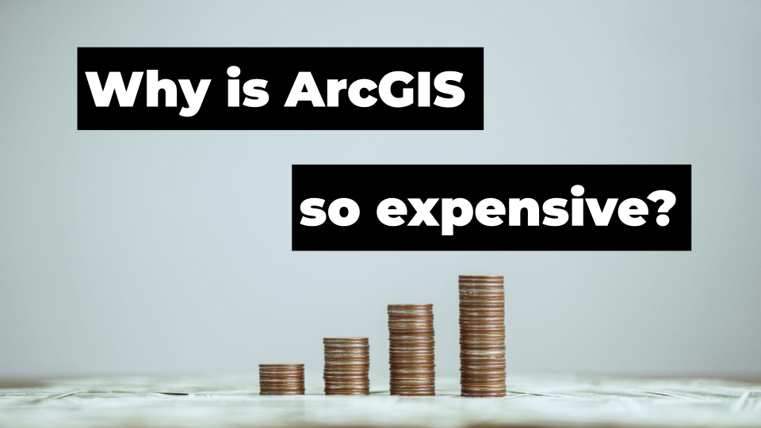

Source: Aleks Buczkowski 2023

- **Disadvantages**
  - Steep learning curve
  - Sometimes harder to quickly look at data

[figure not shown]

## Types of spatial features: vector

- Uses points and/or line segments to identify locations on earth

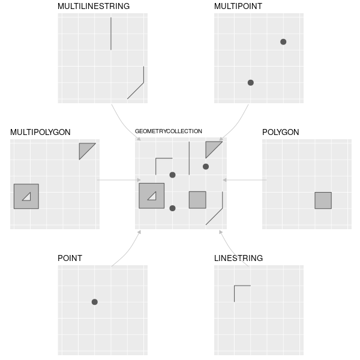

Different types of vectors (Source: Jakub Nowosad)

## R packages for working with vectors

- `sf` (simple features)
- More convenient and flexible than older `sp` package
- Integration with the tidyverse
- Emphasis on the spatial geometry of real world objects

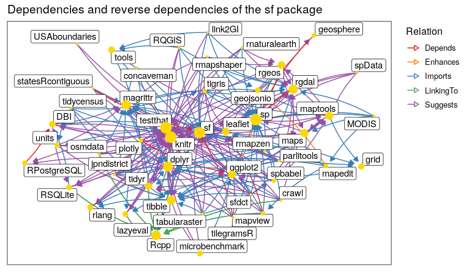

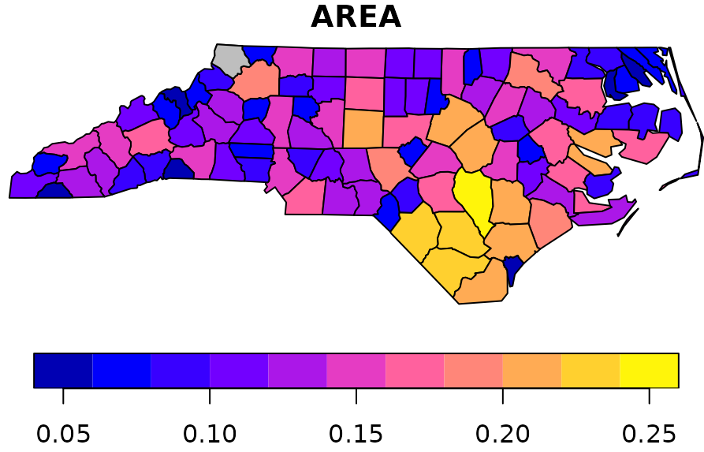

Source: Jakub Nowosad

## Example functions in `sf`

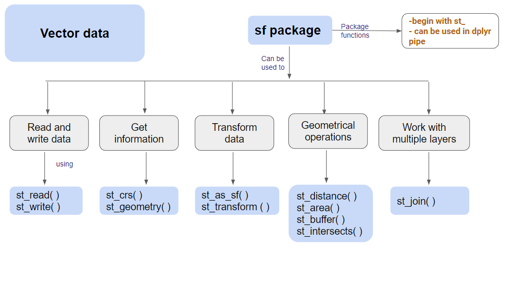

## Types of spatial features: raster

- Gridded data where each pixel (cell) is associated with a specific geographical location
- Commonly used to represent spatially continuous data
- Data can also be categorical

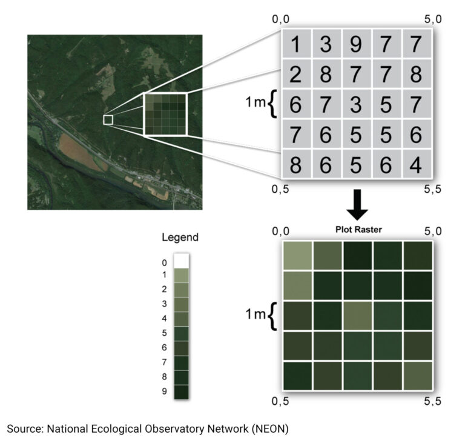

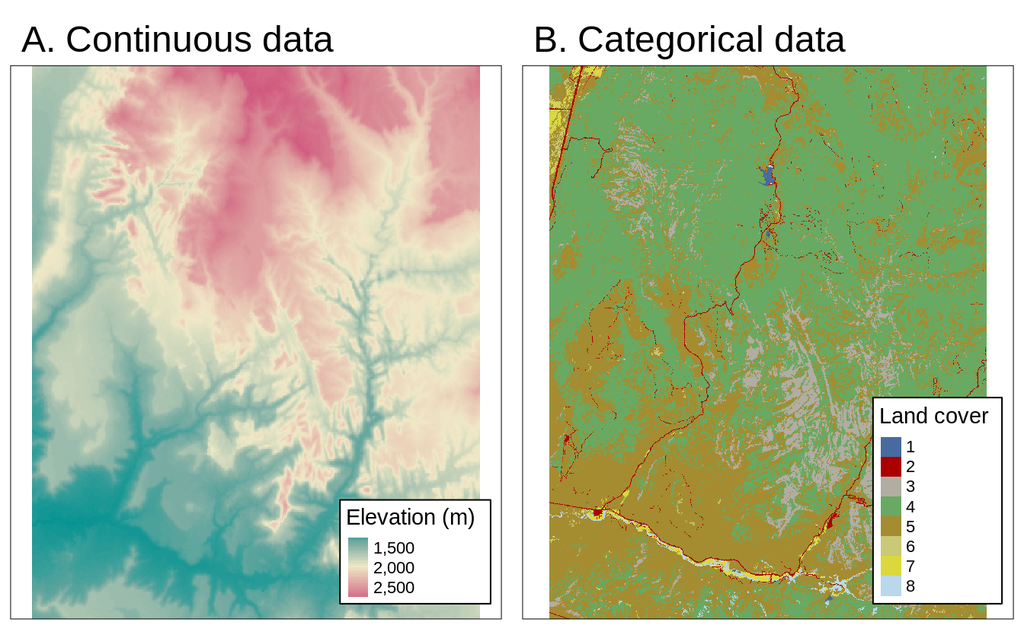

Source: Jakub Nowosad

## Vector vs. raster

Multi-polygon: provinces of Spain

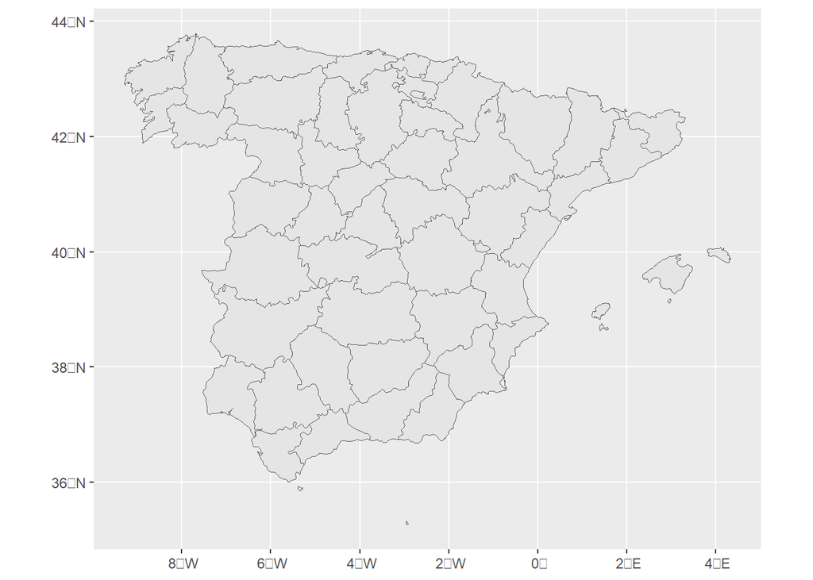

Source: Paula Moraga

Raster: average annual temperature in Spain

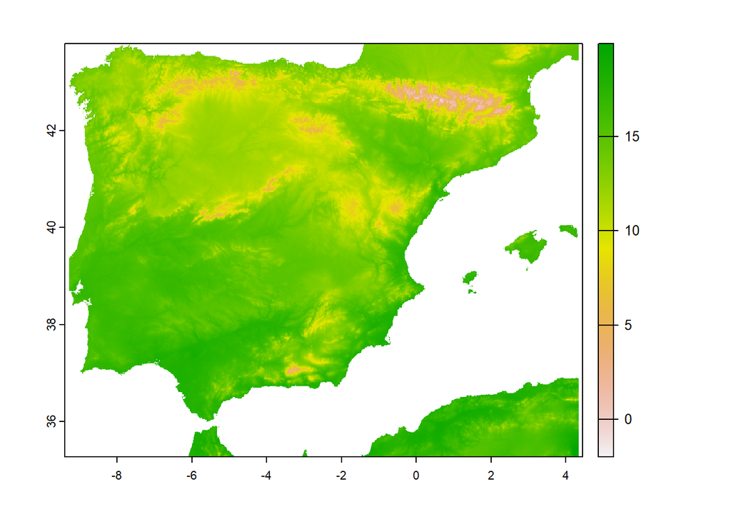

## Types of spatial features: raster

- Multi-layered rasters often called raster stacks
  - Time (day of year, etc.)
  - Different variables

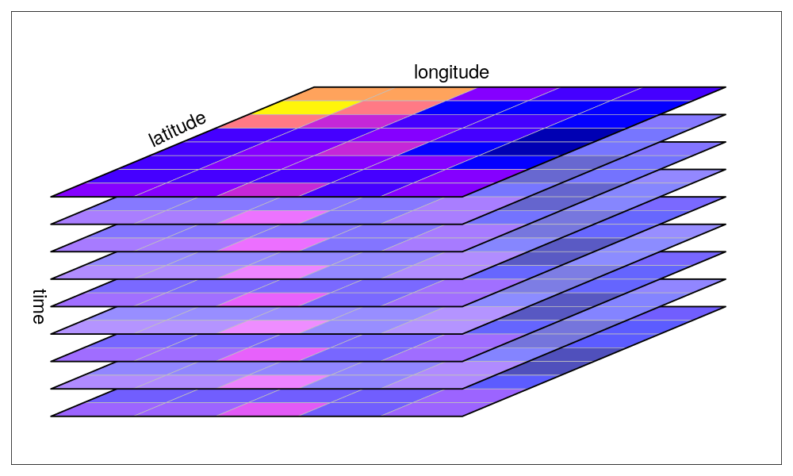

Source: Edzer Pebesama

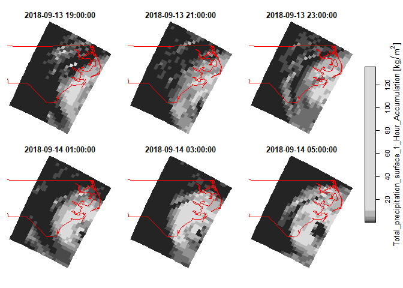

## R packages for working with rasters

- `terra` (successor of `raster`)
  - Create, read/write, manipulate rasters
  - Can also work with vector data
  - Extensive documentation

[figure not shown]

- Hundreds of functions
  - Spatial statistics and modeling
  - Access and extract cell values
  - Plot rasters and vectors

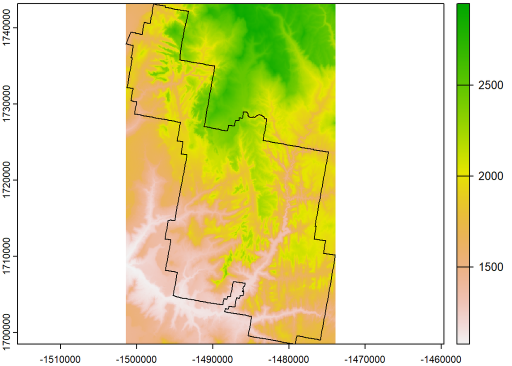

## R packages for working with rasters

- `stars`(spatiotemporal arrays)
  - Has a few abilities lacking in `terra` (e.g., non-regular shapes)
  - Many `sf` functions work with stars objects
  - Not as well documented

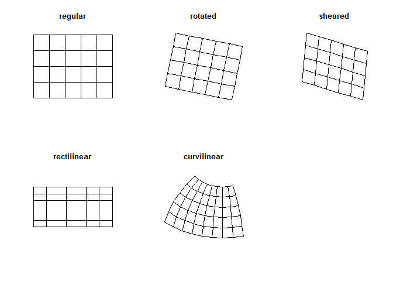

Source: Edzer Pebesama

## Layering

- Oftentimes we want to make maps with multiple spatial features

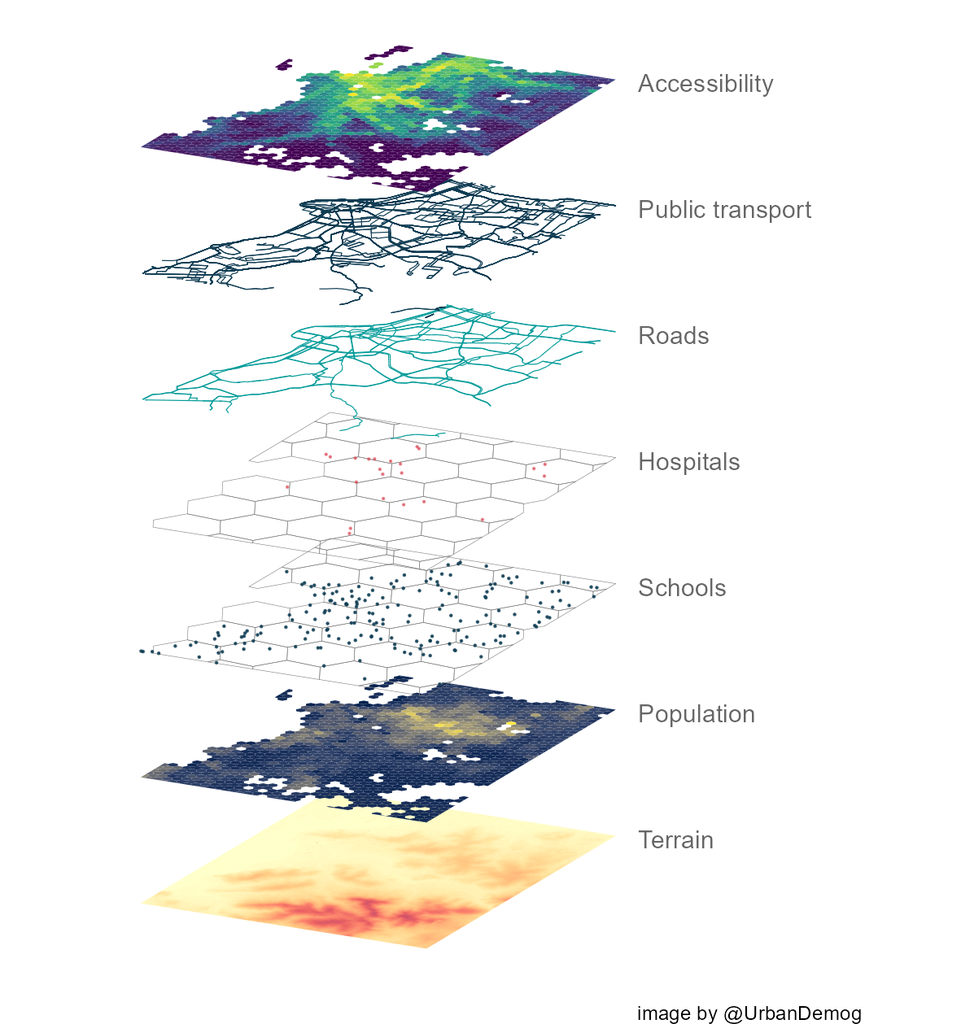

## In comes `ggplot`

- Uses layered approach to create graphics (The Grammar of Graphics)
- You provide the data, tell `ggplot2` how to map variables to aesthetics, what graphical elements to use, and it takes care of the details

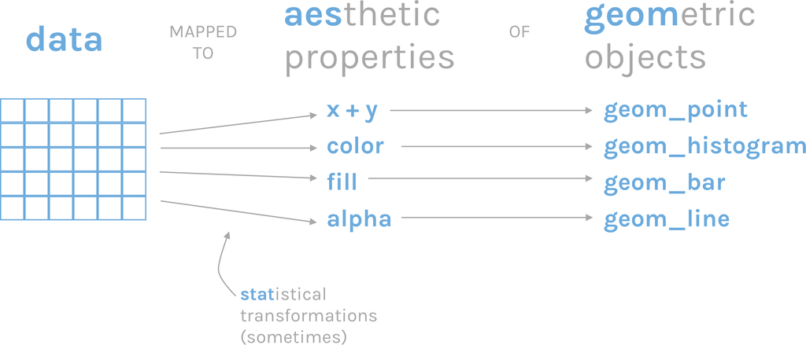

Source: R for the rest of us

## In comes `ggplot`

- `ggplot2` can plot all sorts of data, including rasters and vectors

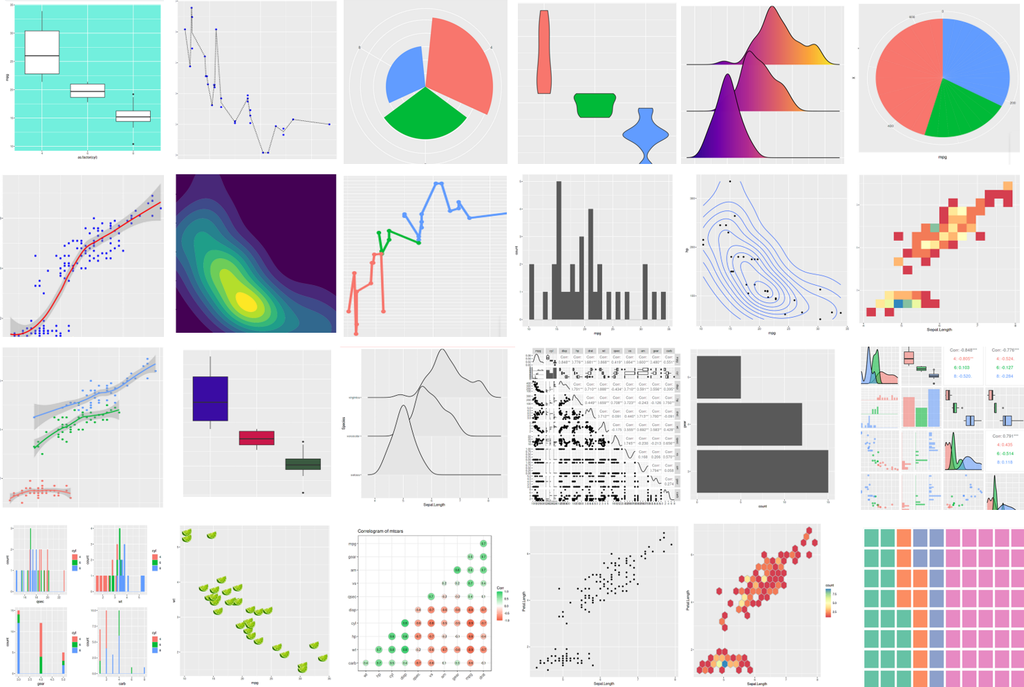

Source: www.icertglobal.com

## `tidyterra`: integrates spatial data with `ggplot`

- Supports a variety of geospatial formats (vector and raster)
- Leverages `dplyr`-like functions (filtering, summarizing, joining, etc.)
- Provides `geoms` for plotting in `ggplot2`

[figure not shown]

Source: Joachim Schork

## Example: a ggplot combining raster and vectors

- Map of the phenology and potential distribution for invasive emerald ash borer
- What are the vectors vs. rasters in this map?

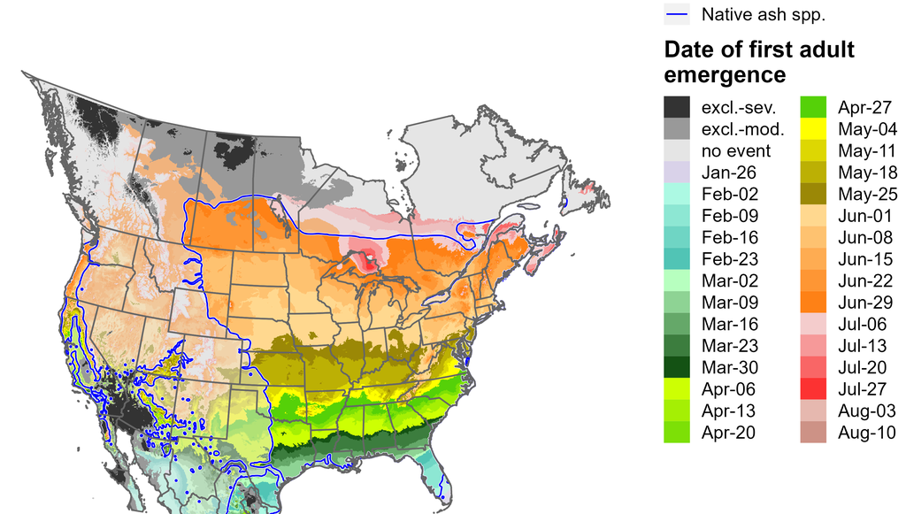

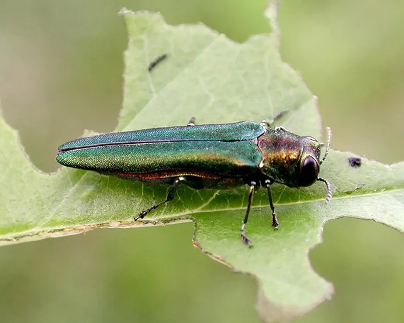

Source: Barker et al. (2023) *Front. Insect Sci.*

## Interactive web maps using `leaflet`

- Create dynamic and interactive maps using Leaflet JavaScript library
- Used for maps in web pages, including Shiny web apps

[figure not shown]

Source: https://i.sstatic.net/O2DAV.gif

## Coordinate reference system (CRS)

- Coordinate system: X, Y grid upon which data is overlaid
- Units: horizontal & vertical units of grid (e.g., km, miles)
- Datum: defines origin used to place the coordinate system in space
- Projection: equation used to flatten objects to 2D surface

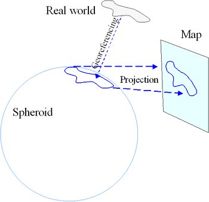

Source: Bill Huber, https://www.directionsmag.com

## Why is the CRS important?

- Framework for precisely measuring locations on earth’s surface
- Errors or mistakes occur when using inconsistent CRS
- For example, mismatched features and incorrect distance measurements